# Text Analysis: Southern United States

Madeleine Ashby

10/13/2021

```r
# Load all necessary packages
library(tidyverse)
library(tidytext)
library(ggwordcloud)
library(gutenbergr)
library(textdata)
library(textreadr)
```

I will be examining regional climate change support through a preliminary text analysis of 15 newspaper articles from publications from the following states (considered to be the South for the purpose of this assignment): * Alabama * Arkansas * Florida * Georgia * Kentucky * Louisiana * Maryland * Mississippi * North Carolina * Oklahoma * South Carolina * Tennessee * Texas * Virginia * West Virginia

To select the articles that will form the South Corpus, I filtered my NexisUni search such that the time frame was Jan 1, 2000 - present, and I searched the database using the following terms/phrases: * climate change * rising sea level * global warming * renewable energy * pollution

The resulting articles from these searches were then selected at random (except I did try to vary which states the articles were coming from in order to eliminate bias).

## Corpus Creation

```r
# Data Prep Function (from lecture)
data_prep <- function(x,y,z){
  i <- as_tibble(t(x)) # pass in data as x
  ii <- unite(i,"text",y:z, remove = TRUE, sep = "")
}
```

```r
# Read in Articles

# Article 1
a1_raw <- as_tibble(read_rtf("C:/Users/Maddie/OneDrive/Desktop/3YEAR/Week8Lab_TextAnalysis/SouthData/Alabama Power proposes increase in renewable energy to.RTF"))[19:37,]
a1_bag <- data_prep(a1_raw, 'V1', 'V19' )


# Article 2
a2_raw <- as_tibble(read_rtf("C:/Users/Maddie/OneDrive/Desktop/3YEAR/Week8Lab_TextAnalysis/SouthData/Annette Taddeo launches campaign to be Florida_s first.RTF"))[20:62,]
a2_bag <- data_prep(a2_raw, 'V1', 'V43')

# Article 3
a3_raw <- as_tibble(read_rtf("C:/Users/Maddie/OneDrive/Desktop/3YEAR/Week8Lab_TextAnalysis/SouthData/Biden faces busy_ critical agenda for next 2 weeks.RTF"))[18:43,]
a3_bag <- data_prep(a3_raw, 'V1', 'V26')

# Article 4
a4_raw <- as_tibble(read_rtf("C:/Users/Maddie/OneDrive/Desktop/3YEAR/Week8Lab_TextAnalysis/SouthData/County_ state get poor grades for air pollution.RTF"))[18:54,]
a4_bag <- data_prep(a4_raw, 'V1', 'V37')

# Article 5
a5_raw <- as_tibble(read_rtf("C:/Users/Maddie/OneDrive/Desktop/3YEAR/Week8Lab_TextAnalysis/SouthData/Drought lowering Edisto River levels_ officials say sit.RTF"))[19:54,]
a5_bag <- data_prep(a5_raw, 'V1', 'V36')

# Article 6
a6_raw <- as_tibble(read_rtf("C:/Users/Maddie/OneDrive/Desktop/3YEAR/Week8Lab_TextAnalysis/SouthData/GLOBAL WARMING_ The state we may be in_How scientists c.RTF"))[19:137, ]
a6_bag <- data_prep(a6_raw, 'V1', 'V119')

# Article 7
a7_raw <- as_tibble(read_rtf("C:/Users/Maddie/OneDrive/Desktop/3YEAR/Week8Lab_TextAnalysis/SouthData/Oklahoma rising_ Global warming_ weather or not.RTF"))[19:43,]
a7_bag <- data_prep(a7_raw, 'V1', 'V25')

# Article 8
a8_raw <- as_tibble(read_rtf("C:/Users/Maddie/OneDrive/Desktop/3YEAR/Week8Lab_TextAnalysis/SouthData/OMU set to present solar team findings.RTF"))[19:32,]
a8_bag <- data_prep(a8_raw, 'V1', 'V14')

# Article 9
a9_raw <- as_tibble(read_rtf("C:/Users/Maddie/OneDrive/Desktop/3YEAR/Week8Lab_TextAnalysis/SouthData/Political Insider_ Barr on _Colbert__ So close to a dis.RTF"))[21:39,]
a9_bag <- data_prep(a9_raw, 'V1', 'V19')

# Article 10
a10_raw <- as_tibble(read_rtf("C:/Users/Maddie/OneDrive/Desktop/3YEAR/Week8Lab_TextAnalysis/SouthData/REPORT REVEALS POLLUTION IS LOCAL.RTF"))[17:19,]
a10_bag <- data_prep(a10_raw, 'V1', 'V3')

# Article 11
a11_raw <- as_tibble(read_rtf("C:/Users/Maddie/OneDrive/Desktop/3YEAR/Week8Lab_TextAnalysis/SouthData/Rising sea levels fuel damage.RTF"))[19:37,]
a11_bag <- data_prep(a11_raw, 'V1', 'V19')

# Article 12
a12_raw <- as_tibble(read_rtf("C:/Users/Maddie/OneDrive/Desktop/3YEAR/Week8Lab_TextAnalysis/SouthData/Rising sea levels pose significant risk to owners of le.RTF"))[18:25,]
a12_bag <- data_prep(a12_raw, 'V1', 'V8')

# Article 13
a13_raw <- as_tibble(read_rtf("C:/Users/Maddie/OneDrive/Desktop/3YEAR/Week8Lab_TextAnalysis/SouthData/Satellites show warming accelerating sea level rise.RTF"))[18:35,]
a13_bag <- data_prep(a13_raw, 'V1', 'V18')

# Article 14
a14_raw <- as_tibble(read_rtf("C:/Users/Maddie/OneDrive/Desktop/3YEAR/Week8Lab_TextAnalysis/SouthData/Something in the Air_ Report_ Particulates an issue in.RTF"))[19:31,]
a14_bag <- data_prep(a14_raw, 'V1', 'V13')

# Article 15
a15_raw <- as_tibble(read_rtf("C:/Users/Maddie/OneDrive/Desktop/3YEAR/Week8Lab_TextAnalysis/SouthData/YOUR VIEWS_ GLOBAL WARMING_EDUCATION _ Al Gore_s global.RTF"))[18:44,]
a15_bag <- data_prep(a15_raw, 'V1', 'V27')
```

```r
# Create corpus variable

article_label <- paste(rep('Article', 15), 1:15, sep = ' ')

south_corpus <- tibble(Article=article_label, text = t(tibble(a1_bag, a2_bag, a3_bag, a4_bag, a5_bag, a6_bag, a7_bag, a8_bag, a9_bag, a10_bag, a11_bag, a12_bag, a13_bag, a14_bag, a15_bag, .name_repair = "universal")))
```

```r
#Save as csv file for future reference!
south <- as.data.frame(south_corpus)
write.csv(south, file="south_corpus.csv")
```

## Sentiment Analysis

```r
# Prepare for analysis by combining all words into one single cell.
south_text <- south_corpus[,2]
south_all <- data_prep(south_text, 'V1', 'V15')

#write to csv for future reference
south_all_words_df <- as.data.frame(south_all)
write.csv(south_all_words_df, file = "south_all_words.csv")
```

```r
# Tokenize to find freqency excluding stop words
south_all_words <- south_all %>%
  unnest_tokens(word, text) %>%
  anti_join(stop_words) %>%
  count(word, sort=TRUE)
```

```r
south_sentiment_afinn <- south_all_words %>%
  inner_join(get_sentiments("afinn"))
south_sentiment_bing <- south_all_words %>%
  inner_join(get_sentiments("bing"))
south_sentiment_nrc <- south_all_words %>%
  inner_join(get_sentiments("nrc"))
```

### Afinn Analysis

Afinn rates words on a scale of -5 to 5. To examine the distribution, a histogram would be best for visualization.

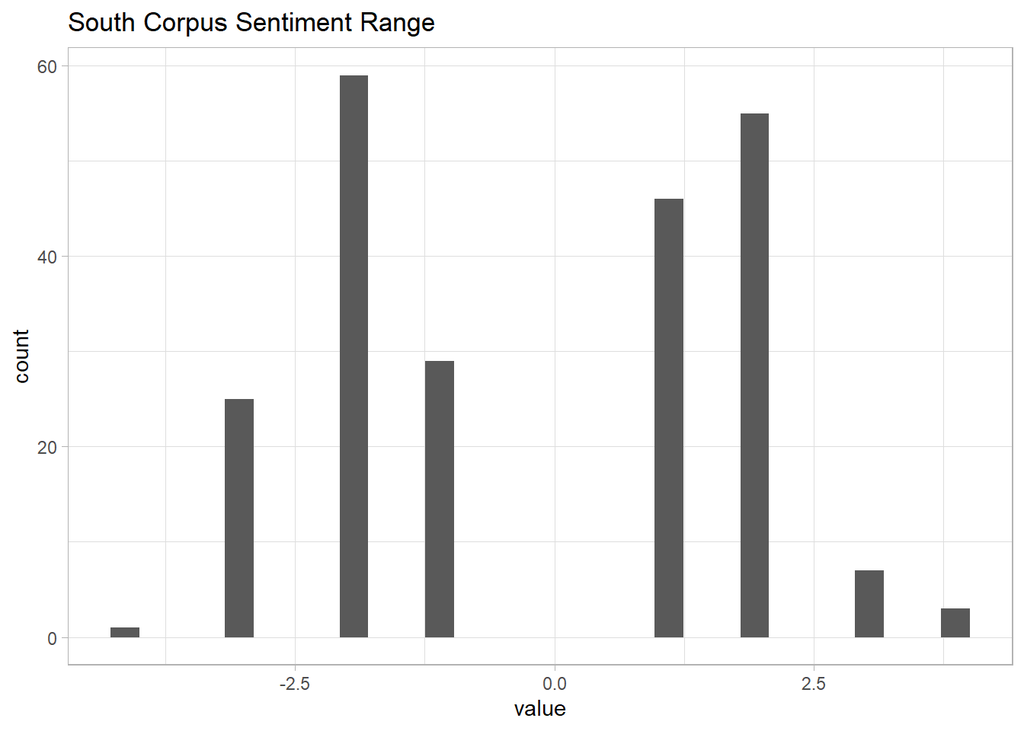

```r
ggplot(data = south_sentiment_afinn,
       aes(x=value)
        )+
  geom_histogram()+
  ggtitle("South Corpus Sentiment Range")+
  theme_light()
```

Based on this histogram, the sentiment distribution appears to be slightly more negative than positive, which suggests a negative average sentiment. However, this is not the best possible analysis as there were only 225 words shared between Afinn and the 5678 words in the corpus.

### Bing Analysis

```r
table(south_sentiment_bing$sentiment)
```

```
##
## negative positive
##      158      121
```

Bing analysis provided a little bit more insight as there were 279 words shared between the two sets. Once again, the sentiment leans towards negative, although this time it is definitely more significant.

### NRC Analysis

```r
table(south_sentiment_nrc$sentiment)
```

```
##
##        anger anticipation      disgust         fear          joy     negative
##           62          104           41           87           67          160
##     positive      sadness     surprise        trust
##          243           67           43          154
```

To verify this, we can perform TF-IDF analysis to see if any more insight is provided.

## TF-IDF Analysis

```r
word_count <- south_corpus %>%
  unnest_tokens(word, text) %>%
  count(Article, word, sort = TRUE)

total_words <- word_count %>%
  group_by(Article) %>%
  count(Article, word, sort = TRUE)

south_words <- left_join(word_count, total_words)

south_words <- south_words %>%
  bind_tf_idf(word, Article, n)
```

### Visualization

```r
# Adjust dataset for visualization purposes

south_words$Article <- as.factor(south_words$Article)
#define levels to maintain order from 1-15
levels(south_words$Article) <- paste(rep('Article', 15), 1:15, sep=' ')
```

I decided to display the top 3 words (by tf-idf) for each article in the South corpus.

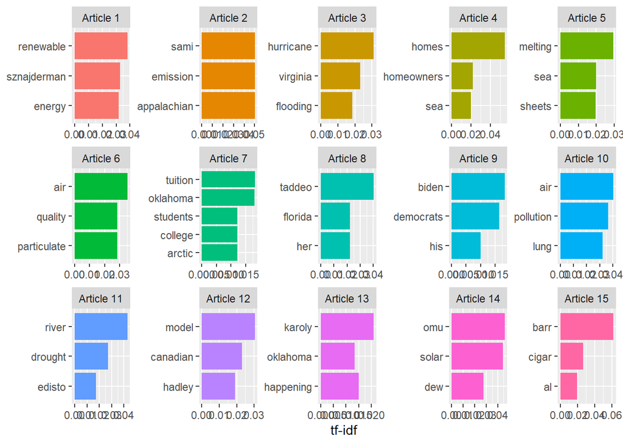

```r
# Plot to show top 3 words for each article in the corpus based on tf_idf
south_words %>%
  group_by(Article) %>%
  slice_max(order_by = tf_idf, n=3) %>% #select top 3 words
  ungroup() %>%
  ggplot(aes(x=tf_idf, fct_reorder(word, tf_idf), fill=Article)) +
  geom_col(show.legend = FALSE) +
  facet_wrap(~Article, ncol=5, scales="free") + #plots for each article
  labs(x="tf-idf", y=NULL, cex.lab=0.4)
```

I quickly noticed the strong presence of words pertaining to air pollution. Words such as “air”, “quality”, “lung”, “cigar”, and “pollution” were quite frequently found in the articles. This suggests that inhabitants of the South are most concerned with air pollution in relation to climate change.

Another trend I found during tf-idf analysis was a general recognition of global warming; words like “melting”, “sheets”, sea“,”river“,”drought“, and”flooding" also had high tf-idf values.

I did not, however, see any words that suggested any desire for legal action in the South. Additionally, based on my previous sentiment analysis, it is fair to assume that mentions of regulations regarding climate change would not be in favor of regulation.

## Word Cloud

I also created a word cloud for a simple visualization of the words found in the corpus and their frequency.

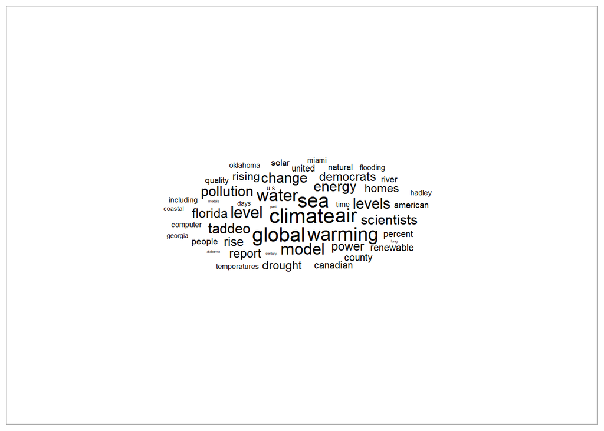

```r
set.seed(42)
ggplot(south_all_words[1:50,], aes(label = word, size = n)
       ) +
  geom_text_wordcloud() +
  theme_light()
```

Obviously the search terms I used are bound to be larger words in this display, but other more frequently used words in the corpus were “model”, “democrats”, “solar”, “power”, and “homes”. The high frequency of these terms shows the slow shift of states (especially those that tend to be democratic) towards alternative energy and power sources.

## Overview of Results & Implications

From my tf-idf analysis, I drew the conclusion that water and air pollution are popular topics of conversation in the South. However, combining these findings with my findings in the sentiment analysis implies that there may not be a huge amount of concern for these issues given that the negative sentiment associated with climate change suggests a general indifference towards the topic. That being said, there were not many frequently occurring words pertaining to steps towards legislation and regulation. Another implication would thus be that the South does not appear to value laws governing climate change, and this is illustrated by the fact that most Southern states are Republican and more conservative.

## Next Steps

A few of the steps I would take next to obtain a better understanding of the general sentiment of the United States towards climate change would be:

1. Change the way the United States was divided for this project. The South is typically a more conservative region and thus is not sufficient to represent the United States as a whole.
2. Use a greater number of articles when creating the corpus.
3. Use articles from a more recent time frame (perhaps from the last 5 years instead of the last 20) in order to make sure that observations made are up-to-date and do not reflect past trends.
4. Isolate action / feeling words to get a better understanding of the sentiment as some words may have negative ratings associated with them but aren’t inherently negative in the article.